# Relatório Final Supercomputação - Comparação de DNA

### Victor Vergara

```python
import matplotlib.pyplot as plt
import os
import numpy as np
import random
import pandas as pd
import time
import subprocess
import pickle
from mpl_toolkits.mplot3d import Axes3D
```

```python
algoritimos = ["./exaustiva", "./random", "./smithWaterman", "./paraleloexaus", "./exaustivaSmithWaterman"]
```

```python
#def createDnaSequences():
nao rodar novamente
seqList= list()
i=0
for n in range(100, 2500, 300):
   for m in range(100, 2500, 300):
        #file = "dna" + str(n) + "-" + str(m) + "-" + str(i)
        file = "dna"+ str(i)
        print(file)
        f = open(file, 'w')


        seq=[str(n)+'\n',
             str(m)+'\n',
             ''.join(random.choices(['A','T','C','G','-'],k=n))+'\n',
             ''.join(random.choices(['A','T','C','G','-'],k=m))]
        f.writelines(seq)
        f.close()
        #seqList.append(seq)
        i += 1
print(i)

    #return seqList
```

[output not shown]

[output cut: 10 more lines]

```
dna50
dna51
dna52
dna53
dna54
dna55
dna56
dna57
dna58
dna59
dna60
dna61
dna62
dna63
64
```

```python
def roda_com_entrada(ex, in_f):
    with open(in_f) as f:
        start = time.perf_counter()
        proc = subprocess.run([ex], input=f.read(), text=True, capture_output=True)
        end = time.perf_counter()

    return end-start
```

```python
feita
#timeExaustiva = list()
#timeLocal = list()
timeSmithWaterman = list()
#timeParallelLocal = list()
#timeParallelExaustivaSmithWaterman = list()
i = 63
i2 = 1

while i2<=i :
    seq = "dna" + str(i2)
    '''t1 = roda_com_entrada(algoritimos[0], seq)
    timeExaustiva.append(t1)
    t2 = roda_com_entrada(algoritimos[1], seq)
    timeLocal.append(t2)'''
    t3 = roda_com_entrada(algoritimos[2], seq)
    timeSmithWaterman.append(t3)
    print("I ", i2, " de ", i, " rodado")
    i2 += 1
```

[output not shown]

[output cut: 8 more lines]

```
I  49  de  63  rodado
I  50  de  63  rodado
I  51  de  63  rodado
I  52  de  63  rodado
I  53  de  63  rodado
I  54  de  63  rodado
I  55  de  63  rodado
I  56  de  63  rodado
I  57  de  63  rodado
I  58  de  63  rodado
I  59  de  63  rodado
I  60  de  63  rodado
I  61  de  63  rodado
I  62  de  63  rodado
I  63  de  63  rodado
```

```python
feita
timeExaustiva = list()
#timeLocal = list()
#timeSmithWaterman = list()
#timeParallelLocal = list()
#timeParallelExaustivaSmithWaterman = list()
i = 29
i2 = 0

while i2<= i :
    seq = "dna" + str(i2)
    t1 = roda_com_entrada(algoritimos[0], seq)
    timeExaustiva.append(t1)
    '''
    t2 = roda_com_entrada(algoritimos[1], seq)
    timeLocal.append(t2)
    t3 = roda_com_entrada(algoritimos[2], seq)
    timeSmithWaterman.append(t3)'''
    print("I ", i2, " de ", i, " rodado")
    i2 += 1
```

[output not shown]

```python
feita
#timeExaustiva = list()
timeLocal = list()
#timeSmithWaterman = list()
#timeParallelLocal = list()
#timeParallelExaustivaSmithWaterman = list()
i = 63
i2 = 1

while i2 <= i :
    seq = "dna" + str(i2)
    '''t1 = roda_com_entrada(algoritimos[0], seq)
    timeExaustiva.append(t1)
    '''
    t2 = roda_com_entrada(algoritimos[1], seq)
    timeLocal.append(t2)
    '''t3 = roda_com_entrada(algoritimos[2], seq)
    timeSmithWaterman.append(t3)'''
    print("I ", i2, " de ", i, " rodado")
    i2 += 1
```

[output not shown]

[output cut: 8 more lines]

```
I  49  de  63  rodado
I  50  de  63  rodado
I  51  de  63  rodado
I  52  de  63  rodado
I  53  de  63  rodado
I  54  de  63  rodado
I  55  de  63  rodado
I  56  de  63  rodado
I  57  de  63  rodado
I  58  de  63  rodado
I  59  de  63  rodado
I  60  de  63  rodado
I  61  de  63  rodado
I  62  de  63  rodado
I  63  de  63  rodado
```

```python
# resultados do smithwaterman estao na lista errada
#print(len(timeSmithWaterman))
tamanho1Utilizado = list()
tamanho2Utilizado = list()
i3 = 0
for s1 in range(100, 2500, 300):
   for s2 in range(100, 2500, 300):
        tamanho1Utilizado.append(s1)
        tamanho2Utilizado.append(s2)
        print(s1, "  ", s2)
        i3+= 1
print(i3)
```

```
100    100
100    400
100    700
100    1000
100    1300
100    1600
100    1900
100    2200
400    100
400    400
400    700
400    1000
400    1300
400    1600
400    1900
```

[output cut: 50 more lines]

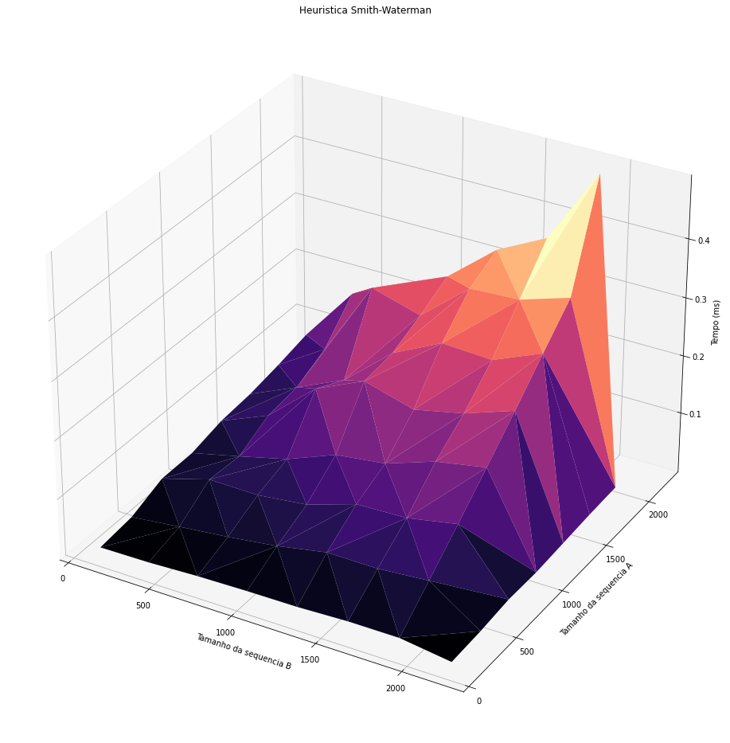

```python
fig = plt.figure(figsize=(55,30))
heuristica_graph = fig.add_subplot(133, projection='3d')
heuristica_graph.plot_trisurf(tamanho2Utilizado[0:-1], tamanho1Utilizado[0:-1], timeSmithWaterman,cmap='magma')
heuristica_graph.set_xlabel('Tamanho da sequencia B')
heuristica_graph.set_ylabel('Tamanho da sequencia A')
heuristica_graph.set_zlabel('Tempo (ms)')
heuristica_graph.set_title('Heuristica Smith-Waterman')
```

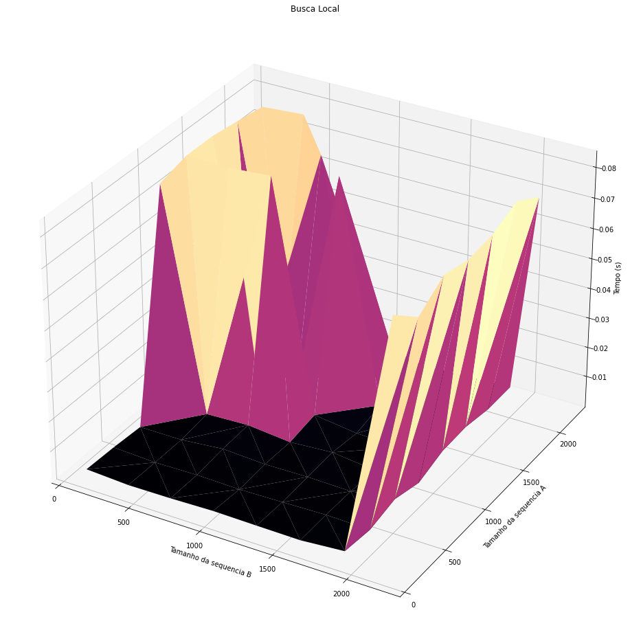

```python
fig = plt.figure(figsize=(55,30))
heuristica_graph = fig.add_subplot(133, projection='3d')
heuristica_graph.plot_trisurf(tamanho2Utilizado[0:-1], tamanho1Utilizado[0:-1], timeLocal,cmap='magma')
heuristica_graph.set_xlabel('Tamanho da sequencia B')
heuristica_graph.set_ylabel('Tamanho da sequencia A')
heuristica_graph.set_zlabel('Tempo (s)')
heuristica_graph.set_title('Busca Local')
```

[output not shown]

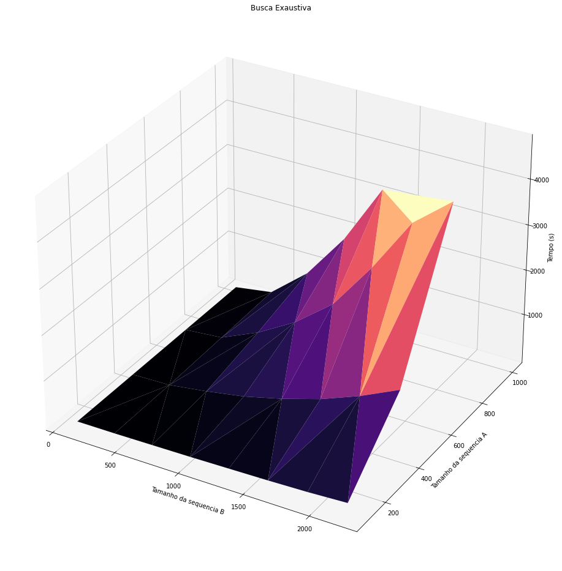

```python
print(len(tamanho2Utilizado))
print(len(tamanho1Utilizado))
print(len(timeExaustiva))
fig = plt.figure(figsize=(55,30))
heuristica_graph = fig.add_subplot(133, projection='3d')
heuristica_graph.plot_trisurf(tamanho2Utilizado[0:29], tamanho1Utilizado[0:29], timeExaustiva,cmap='magma')
heuristica_graph.set_xlabel('Tamanho da sequencia B')
heuristica_graph.set_ylabel('Tamanho da sequencia A')
heuristica_graph.set_zlabel('Tempo (s)')
heuristica_graph.set_title('Busca Exaustiva')
```

## Smith Waterman

A Heurística de Smith-WaterMan é uma boa solução caso queira um balanço entre acurácia e tempo para rodar o algoritimo. O problema de utilizar essa heurística é que ela cria uma matriz m X n (tamanho da primeira sequência X tamanho da segunda sequência), assim para sequências muito grandes a matriz fica muito grande, assim pode gerar um problema para paralelizar o algoritimo, especialmente em GPUs, visto que a memória ocupada pela matriz acaba sendo muito grande podendo passar da memória para os cores.

## Busca Local

A Busca Local é a solução mais rápida na maioria dos casos de entradas médias, mas nos menores casos e em alguns maiores perde para a Smith Waterman. E por utilizar aleatoriedade para escolher as subsequências a serem comparadas o seu resultado não é nem estável nem confiável

## Busca Exaustiva

A Busca Exaustiva sempre retorna o resultado correto, visto que compara todas as possibilidades, com isso esssa busca é a mais demorada por checar todas as possibilidades, 1 por vez

```python
rodado até 29
#timeExaustiva = list()
#timeLocal = list()
#timeSmithWaterman = list()
timeParallelLocal = list()
#timeParallelExaustivaSmithWaterman = list()
i = 63
i2 = 30

while i2 <= i :
    seq = "dna" + str(i2)
    '''t1 = roda_com_entrada(algoritimos[0], seq)
    timeExaustiva.append(t1)

    t2 = roda_com_entrada(algoritimos[1], seq)
    timeLocal.append(t2)
    t3 = roda_com_entrada(algoritimos[2], seq)
    timeSmithWaterman.append(t3)'''
    t4 = roda_com_entrada(algoritimos[3], seq)
    timeParallelLocal.append(t4)
    print("I ", i2, " de ", i, " rodado")
    i2 += 1
```

[output not shown]

[output not shown]

```python
rodado no collab, por não conseguir rodar no meu computador, mesmo com o cuda instalado e rodando outros arquivos .cu
Dando esse erro ao compilar:

error: parameter packs not expanded with ‘...’:
  530 |         operator=(_Functor&& __f)


#timeExaustiva = list()
#timeLocal = list()
#timeSmithWaterman = list()
#timeParallelLocal = list()
timeParallelExaustivaSmithWaterman = list()
i = 63
i2 = 0

while i2 <= i :
    seq = "dna" + str(i2)
    '''t1 = roda_com_entrada(algoritimos[0], seq)
    timeExaustiva.append(t1)

    t2 = roda_com_entrada(algoritimos[1], seq)
    timeLocal.append(t2)
    t3 = roda_com_entrada(algoritimos[2], seq)
    timeSmithWaterman.append(t3)
    t4 = roda_com_entrada(algoritimos[1], seq)
    timeParallelLocal.append(t2)'''
    t5 = roda_com_entrada(algoritimos[4], seq)
    timeParallelExaustivaSmithWaterman.append(t5)
    print("I ", i2, " de ", i, " rodado")
    i2 += 1
```

```python
#passando dados do colab (GPU paralelizada para o jupyter local)

timeParallelExaustivaSmithWaterman = [0.28220642299993415, 2.389917645999958, 4.44969825599992, 6.62830572599978, 8.72108811399994, 11.021436551000079, 12.833352487999946, 14.52565124900002, 2.3399899690002712, 0.27553624699976353, 8.72990579999987, 16.907847189999757, 24.934474468999724, 33.10098199000004, 41.44178240800011, 49.28199248200008, 4.430583535999631, 8.653270692000206, 0.3115451080002458, 14.91457440699969, 29.396547808000378, 43.89773911099974, 58.1408310439997, 72.87689126600026, 6.657607693000045, 16.939422576999732, 14.824976319000143, 0.32989945400004217, 21.032876074999876, 41.9244014599999, 62.554721014999814, 82.53855910699986, 8.633056529999976, 25.13890357399987, 29.416328536000037, 21.00569118500016, 0.3569105869996747, 27.479576626999915, 54.57433792399979, 81.83035052000014, 10.916911045999768, 33.01631356600001, 43.897940903999825, 42.12020940599996, 27.289822796999943, 0.3872354350000933, 33.445455203000165, 67.18483758899993, 12.673532873999648, 41.61148449300026, 60.06209150199993, 64.62264348899998, 53.74274060400012, 33.658096860000114, 0.4006361750002725, 39.42696650500011, 14.718275747000007, 49.81160618600006, 73.90626761000021, 83.84256672500032, 82.62656622900022, 67.23211292900032, 39.77110657200046, 0.42874475099961273]
```

[output not shown]

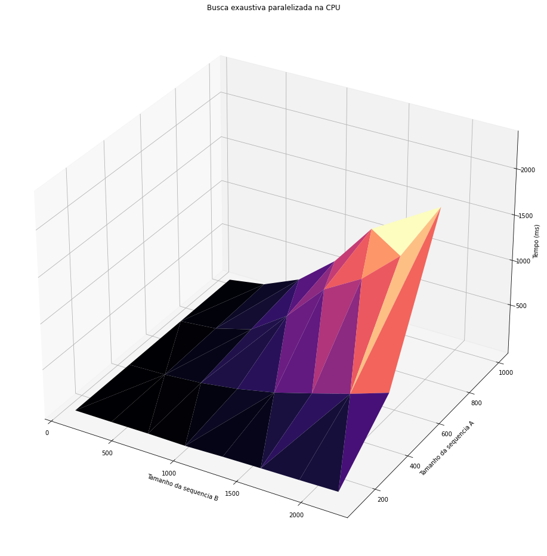

```python
print(len(tamanho2Utilizado))
print(len(tamanho1Utilizado))
print(len(timeParallelLocal))
fig = plt.figure(figsize=(55,30))
heuristica_graph = fig.add_subplot(133, projection='3d')
heuristica_graph.plot_trisurf(tamanho2Utilizado[0:29], tamanho1Utilizado[0:29], timeParallelLocal,cmap='magma')
heuristica_graph.set_xlabel('Tamanho da sequencia B')
heuristica_graph.set_ylabel('Tamanho da sequencia A')
heuristica_graph.set_zlabel('Tempo (ms)')
heuristica_graph.set_title('Busca exaustiva paralelizada na CPU')
```

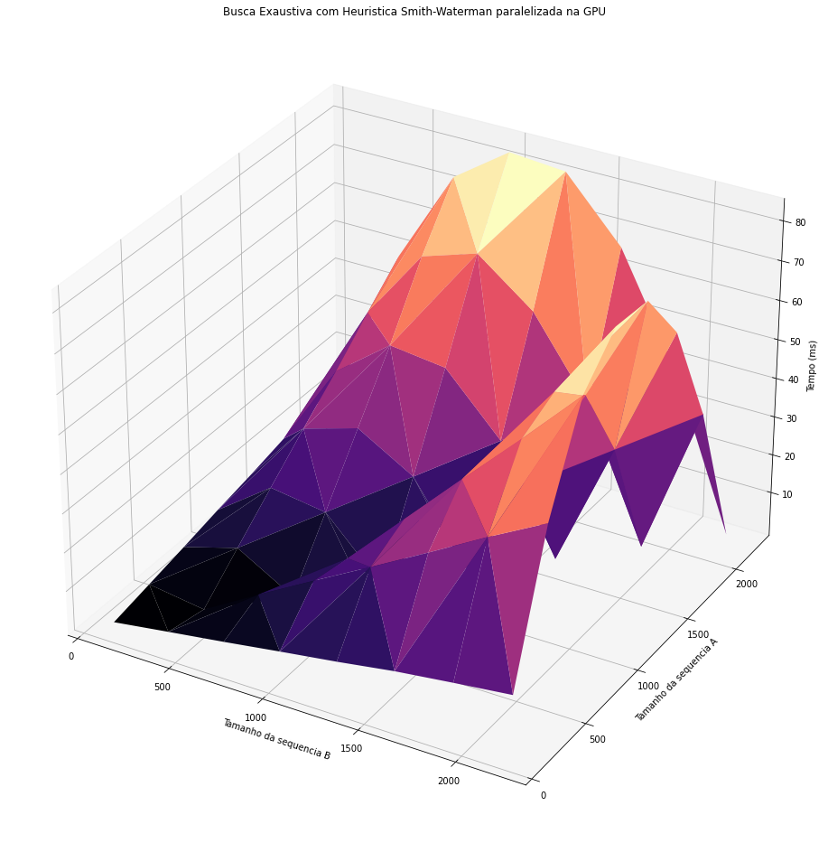

```python
fig = plt.figure(figsize=(55,30))
heuristica_graph = fig.add_subplot(133, projection='3d')
heuristica_graph.plot_trisurf(tamanho2Utilizado, tamanho1Utilizado, timeParallelExaustivaSmithWaterman,cmap='magma')
heuristica_graph.set_xlabel('Tamanho da sequencia B')
heuristica_graph.set_ylabel('Tamanho da sequencia A')
heuristica_graph.set_zlabel('Tempo (ms)')
heuristica_graph.set_title('Busca Exaustiva com Heuristica Smith-Waterman paralelizada na GPU')
```

## Busca Exaustiva Paralelizada na CPU

A Exaustiva é a versão mais demorada do algoritimo, mas sempre chega no resultado correto. Mesmo sendo paralelizado para os 4 cores, 8 threds do computador ainda é muito mais demorada que a sequecial da busca Local e Heurística de Smith-Waterman, mas roda mais de 2X mais rápido que a sua versão sequencial.

## Busca Exaustiva Com Heurística de Smith-Waterman

Pelas complicações para rodar o código no mesmo computador que os outros algoritimos foi necessário rodar essa versão do algoritimo no google collab, por isso não se pode comparar os resultados de tempo com os outros códigos. Mas ao analizar o gráfico pode-se perceber que ela é mais rápida quando as duas sequências são de tamanhos próximos